# COVID_19_Data

## 11. Modeling US_by_State

- Is the number of cases leveling off in a **state**. Add to our data, and transform again. Adding new variables.

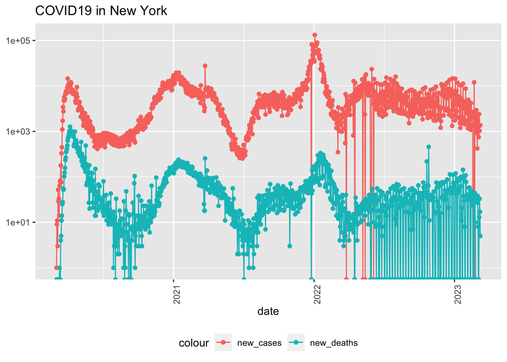

```r
state<- "New York"
US_by_State %>%
  filter(Province_State == state) %>%
  filter(cases > 0) %>%
  ggplot(aes(x = date, y = new_cases)) +
  geom_line(aes(color = "new_cases")) +
  geom_point(aes(color = "new_cases")) +
  geom_line(aes(y = new_deaths, color = "new_deaths")) +
  geom_point(aes(y = new_deaths, color = "new_deaths")) +
  scale_y_log10() +
  theme(legend.position ="bottom", axis.text.x = element_text(angle = 90)) +
  labs(title = str_c("COVID19 in ", state), y=NULL)
```

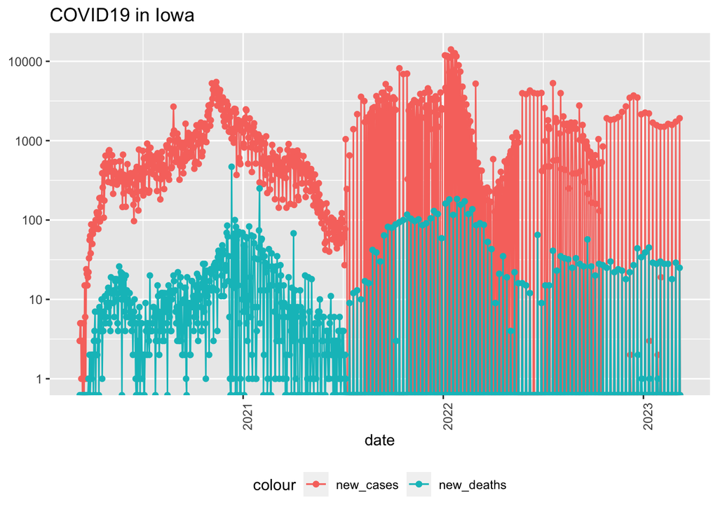

```r
#Check out data for "Iowa"
state<- "Iowa"
US_by_State %>%
  filter(Province_State == state) %>%
  filter(cases > 0) %>%
  ggplot(aes(x = date, y = new_cases)) +
  geom_line(aes(color = "new_cases")) +
  geom_point(aes(color = "new_cases")) +
  geom_line(aes(y = new_deaths, color = "new_deaths")) +
  geom_point(aes(y = new_deaths, color = "new_deaths")) +
  scale_y_log10() +
  theme(legend.position ="bottom", axis.text.x = element_text(angle = 90)) +
  labs(title = str_c("COVID19 in ", state), y=NULL)
```

## 12. What are the worst and Best States, and how do we measure this?

- Total cases or death rate per 1000 people? (in class analysis)

```r
#New varible to store data
#Choosing maximum for deaths and cases
US_state_totals <- US_by_State %>%
  group_by(Province_State) %>%
  summarize(deaths =max(deaths), cases = max(cases), population = max(Population), cases_per_thou = 1000* cases / population, deaths_per_thou = 1000* deaths / population) %>%
  filter(cases >0, population >0)

#use verb- "slice_min"-- show the 10 states with the smallest deaths per 1,000.
US_state_totals %>%
  slice_min(deaths_per_thou, n = 10)
```

```
## # A tibble: 10 × 6
##    Province_State        deaths  cases population cases_per_thou deaths_per_thou
##    <chr>                  <dbl>  <dbl>      <dbl>          <dbl>           <dbl>
##  1 American Samoa            34 8.32e3      55641           150.           0.611
##  2 Northern Mariana Isl…     41 1.37e4      55144           248.           0.744
##  3 Virgin Islands           130 2.48e4     107268           231.           1.21
##  4 Hawaii                  1841 3.81e5    1415872           269.           1.30
##  5 Vermont                  929 1.53e5     623989           245.           1.49
##  6 Puerto Rico             5823 1.10e6    3754939           293.           1.55
##  7 Utah                    5298 1.09e6    3205958           340.           1.65
##  8 Alaska                  1486 3.08e5     740995           415.           2.01
##  9 District of Columbia    1432 1.78e5     705749           252.           2.03
## 10 Washington             15683 1.93e6    7614893           253.           2.06
```

```r
# To see the states with the lowest deaths per thousand.
US_state_totals %>%
  slice_min(deaths_per_thou, n = 10) %>%
  select(deaths_per_thou, cases_per_thou, everything())
```

```
## # A tibble: 10 × 6
##    deaths_per_thou cases_per_thou Province_State        deaths  cases population
##              <dbl>          <dbl> <chr>                  <dbl>  <dbl>      <dbl>
##  1           0.611           150. American Samoa            34 8.32e3      55641
##  2           0.744           248. Northern Mariana Isl…     41 1.37e4      55144
##  3           1.21            231. Virgin Islands           130 2.48e4     107268
##  4           1.30            269. Hawaii                  1841 3.81e5    1415872
##  5           1.49            245. Vermont                  929 1.53e5     623989
##  6           1.55            293. Puerto Rico             5823 1.10e6    3754939
##  7           1.65            340. Utah                    5298 1.09e6    3205958
##  8           2.01            415. Alaska                  1486 3.08e5     740995
##  9           2.03            252. District of Columbia    1432 1.78e5     705749
## 10           2.06            253. Washington             15683 1.93e6    7614893
```

```r
#Look at the worst cases
US_state_totals %>%
  slice_max(deaths_per_thou, n = 10) %>%
  select(deaths_per_thou, cases_per_thou, everything())
```

```
## # A tibble: 10 × 6
##    deaths_per_thou cases_per_thou Province_State deaths   cases population
##              <dbl>          <dbl> <chr>           <dbl>   <dbl>      <dbl>
##  1            4.55           336. Arizona         33102 2443514    7278717
##  2            4.54           326. Oklahoma        17972 1290929    3956971
##  3            4.49           333. Mississippi     13370  990756    2976149
##  4            4.44           359. West Virginia    7960  642760    1792147
##  5            4.32           320. New Mexico       9061  670929    2096829
##  6            4.31           334. Arkansas        13020 1006883    3017804
##  7            4.29           335. Alabama         21032 1644533    4903185
##  8            4.28           368. Tennessee       29263 2515130    6829174
##  9            4.23           307. Michigan        42205 3064125    9986857
## 10            4.06           385. Kentucky        18130 1718471    4467673
```

## 13. Modeling and Communicating your Results

- Linear trends as predictions (in class analysis)

```r
#Linear modeling
mod<- lm(deaths_per_thou ~ cases_per_thou, data = US_state_totals)
summary(mod)
```

```
##
## Call:
## lm(formula = deaths_per_thou ~ cases_per_thou, data = US_state_totals)
##
## Residuals:
##     Min      1Q  Median      3Q     Max
## -2.3352 -0.5978  0.1491  0.6535  1.2086
##
## Coefficients:
##                Estimate Std. Error t value Pr(>|t|)
## (Intercept)    -0.36167    0.72480  -0.499     0.62
## cases_per_thou  0.01133    0.00232   4.881 9.76e-06 ***
## ---
## Signif. codes:  0 '***' 0.001 '**' 0.01 '*' 0.05 '.' 0.1 ' ' 1
##
## Residual standard error: 0.8615 on 54 degrees of freedom
## Multiple R-squared:  0.3061, Adjusted R-squared:  0.2933
## F-statistic: 23.82 on 1 and 54 DF,  p-value: 9.763e-06
```

```r
US_state_totals %>% slice_min(cases_per_thou)
```

```
## # A tibble: 1 × 6
##   Province_State deaths cases population cases_per_thou deaths_per_thou
##   <chr>           <dbl> <dbl>      <dbl>          <dbl>           <dbl>
## 1 American Samoa     34  8320      55641           150.           0.611
```

```r
US_state_totals %>% slice_max(cases_per_thou)
```

```
## # A tibble: 1 × 6
##   Province_State deaths  cases population cases_per_thou deaths_per_thou
##   <chr>           <dbl>  <dbl>      <dbl>          <dbl>           <dbl>
## 1 Rhode Island     3870 460697    1059361           435.            3.65
```

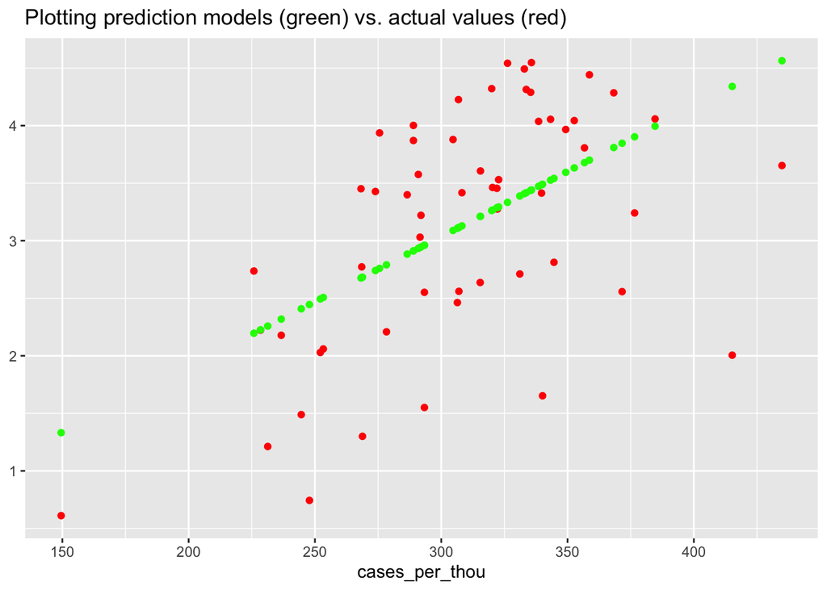

```r
#make a grid from min to max (150 to 435)
x_grid <-seq(145, 450)
#put into tibble
new_df <-tibble(cases_per_thou = x_grid)

# Add it to a new data set
US_tot_w_pred <-US_state_totals %>% mutate(pred = predict((mod)))
#Plot actuals and predictions to see how they compare
US_tot_w_pred %>% ggplot() +
  geom_point(aes(x = cases_per_thou, y = deaths_per_thou), color = "red") +
  geom_point(aes(x = cases_per_thou, y = pred), color = "green") +
  labs(title = "Plotting prediction models (green) vs. actual values (red)", y=NULL)
```

## 14. Additonal Modeling and Analyzing for Final Project

- Plotting Deaths Per Thousand for all states ranked to visually compare easily on a bar graph.
- Political Party Affiliation for each state– how it relates to deaths and cases. Data was taken from “https://www.cnn.com/election/2020/results/president”
- Each state listed as Republican (Red), Democrat (Blue), or NA (gray)

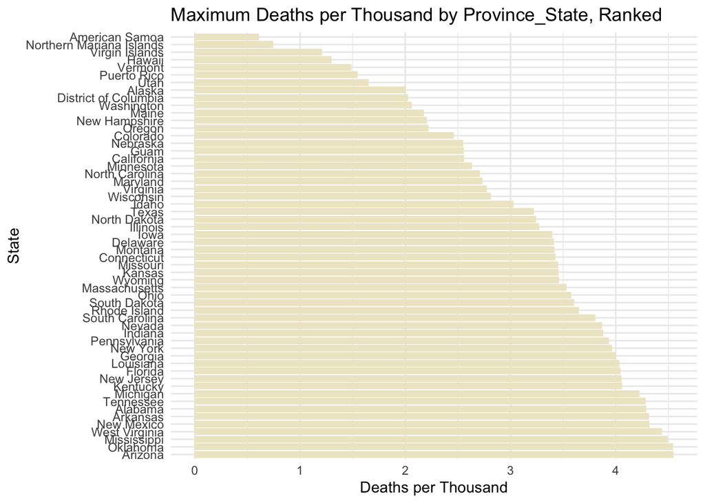

```r
#Plotting Deaths Per Thousand for all states
ggplot(US_state_totals, aes(x = reorder(Province_State, -deaths_per_thou), y = deaths_per_thou)) +
  geom_bar(stat = "identity", fill = "cornsilk2") +
  coord_flip() +  # This will make the chart horizontal, which is often easier to read for state names.
  labs(title = "Maximum Deaths per Thousand by Province_State, Ranked", x = "State", y = "Deaths per Thousand") +
  theme_minimal()
```

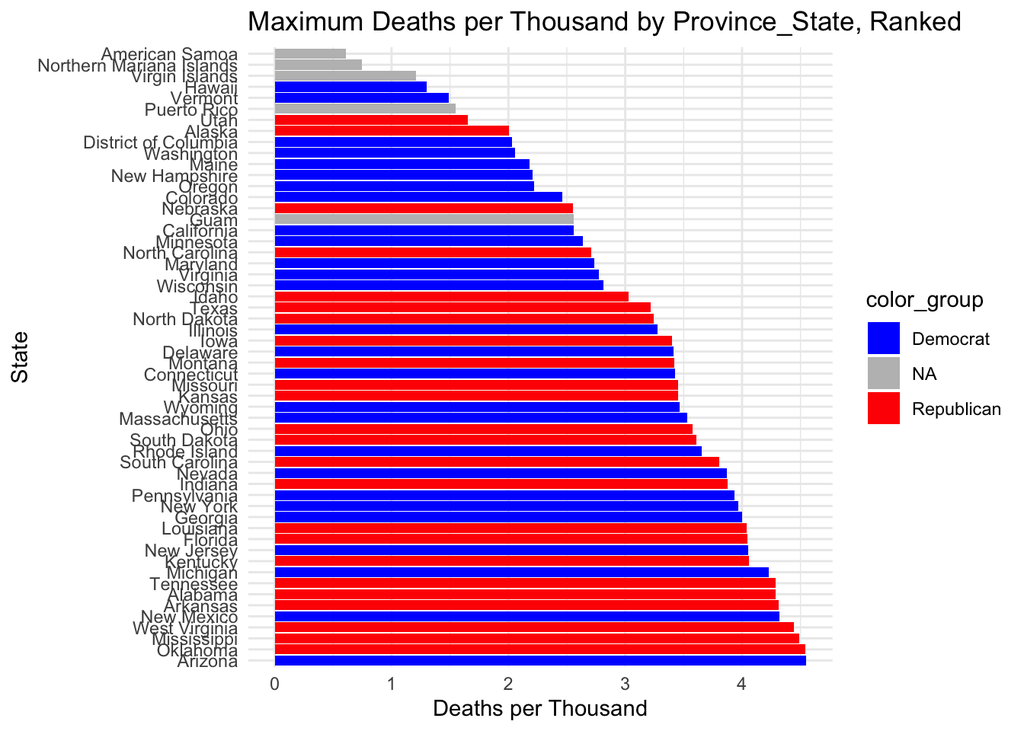

```r
#How did each state vote?
# Modify the 'color_group' column
US_state_totals$color_group <- ifelse(
  US_state_totals$Province_State %in% c("Alabama", "Alaska", "Arkansas", "Florida", "Idaho",
                                        "Indiana", "Iowa", "Kansas", "Kentucky", "Louisiana",
                                        "Mississippi", "Missouri", "Montana", "Nebraska",
                                        "North Carolina", "North Dakota", "Ohio", "Oklahoma",
                                        "South Carolina", "South Dakota", "Tennessee", "Texas",
                                        "Utah", "West Virginia"),
  "Republican",
  ifelse(US_state_totals$Province_State %in% c("American Samoa", "Northern Mariana Islands",
                                               "Virgin Islands", "Puerto Rico", "Guam"),
         "NA",
         "Democrat")
)

# Plot with custom colors
ggplot(US_state_totals, aes(x = reorder(Province_State, -deaths_per_thou), y = deaths_per_thou, fill = color_group)) +
  geom_bar(stat = "identity") +
  scale_fill_manual(values = c("Republican" = "red", "NA" = "gray", "Democrat" = "blue")) +
  coord_flip() +
  labs(title = "Maximum Deaths per Thousand by Province_State, Ranked", x = "State", y = "Deaths per Thousand") +
  theme_minimal()
```